# Practica Fundamentos

Juan José, Moncef y Jose

17/12/2021

## INTRODUCCIÓN

Para la realización de la práctica se ha selecionado un base de datos con los precios de viviendas del barrio King County del estado de Washington(EEUU). Base de datos descargada de: https://www.kaggle.com/swathiachath/kc-housesales-data Para la realización del procto se emplean las siguientes librerías.

- MASS
- emmeans
- stargazer
- nortest
- tydyr
- date
- zoo
- tidyverse
- ggplot2
- corrplot
- caret
- dplyr
- olsrr
- fastDummies
- pracma
- geosphere
- readxl
- glmnet
- mice
- missForest
- VIM
- readr
- naniar
- gridExtra
- grid
- lattice
- GGally

## OBJETIVOS

El objetivo de la práctica será la elaboracion de un informe de un proyecto de Ciencia de Datos en R Markdown. Se emplearán las técnicas aprendidas durante el curso para el estudio del dataframe seleccionado.

### Objetivos generales

- Analisis de la variable **“price”** como objetivo. Se realizarán transformacioes.
- Aplicar un modelo de regresión lineal para tratar de inferir la variable **“price”** o sus posteriores transformaciones.

### Objetivos generales

1. Separación de datos en 2 grupos: train y test.
2. Realización de un análisis exploratorio inicial del dataframe.
3. Detección e imputación de datos faltantes.
4. Transformación de varaibles de interés.
5. Aplicar un modelo de regresión lineal válido la predición de la variable precio de venta.

## CARGA DE DATOS

Lectura de datos, separación TRAIN vs TEST

```r
#Cargamos los datos y definimos una muestra train y otra test

train <- as.data.frame(read.csv(file = 'C:/Users/Juanjo/Desktop/MasterDataScience/Practica/PullBueno/otra/train.csv'))
```

## ANÁLISIS EDA

Se realiza un análisis exploratorio inicial para observar las varaibles.

### Analisis de datos actuales

**Datos actuales**

```r
str(train)
```

```
## 'data.frame':    15979 obs. of  30 variables:
##  $ lat                    : num  47.2 47.2 47.2 47.2 47.2 ...
##  $ long                   : num  -122 -122 -122 -122 -122 ...
##  $ id                     : num  6.19e+08 6.19e+08 6.19e+08 3.42e+09 3.22e+09 ...
##  $ date                   : chr  "20140602T000000" "20150406T000000" "20140619T000000" "20140825T000000" ...
##  $ price                  : int  687000 750000 335000 360000 432000 230000 790000 265000 350000 330000 ...
##  $ bedrooms               : int  4 3 4 4 5 3 3 3 4 3 ...
##  $ bathrooms              : num  3.25 2.5 2 1.75 2.75 1 2.5 1.75 2.25 2.5 ...
##  $ sqft_living            : int  4400 2350 2030 3730 2060 1530 2640 1820 1570 2060 ...
##  $ sqft_lot               : int  186846 715690 103672 16980 329903 389126 432036 32666 499571 25046 ...
##  $ floors                 : num  2 1.5 1 1 1.5 1.5 1.5 1 1 1 ...
##  $ waterfront             : int  0 0 0 0 0 0 0 0 0 0 ...
##  $ view                   : int  0 0 0 0 3 0 3 0 3 0 ...
##  $ condition              : int  4 4 4 4 5 4 3 4 4 4 ...
##  $ grade                  : int  9 9 7 7 7 7 10 7 7 8 ...
```

[output cut: 16 more lines]

### Variables cuantitativas

```r
var_cuant <- train[, c("price", "sqft_living", "sqft_living15", "sqft_lot", "sqft_lot15", "sqft_above", "sqft_basement", "yr_built", "yr_renovated")]
str(var_cuant)
```

```
## 'data.frame':    15979 obs. of  9 variables:
##  $ price        : int  687000 750000 335000 360000 432000 230000 790000 265000 350000 330000 ...
##  $ sqft_living  : int  4400 2350 2030 3730 2060 1530 2640 1820 1570 2060 ...
##  $ sqft_living15: int  2280 1280 1560 1880 2240 1768 1500 2050 1700 2050 ...
##  $ sqft_lot     : int  186846 715690 103672 16980 329903 389126 432036 32666 499571 25046 ...
##  $ sqft_lot15   : int  186846 325393 325393 16963 220232 42148 560617 43560 181708 21255 ...
##  $ sqft_above   : int  4400 2350 2030 2150 2060 1530 2640 1820 1570 1600 ...
##  $ sqft_basement: int  0 0 0 1580 0 0 0 0 0 460 ...
##  $ yr_built     : int  1993 1979 1969 1974 1989 1919 1996 1966 1972 1980 ...
##  $ yr_renovated : int  0 0 0 0 0 0 0 0 0 0 ...
```

Se estudia la variable **precio**

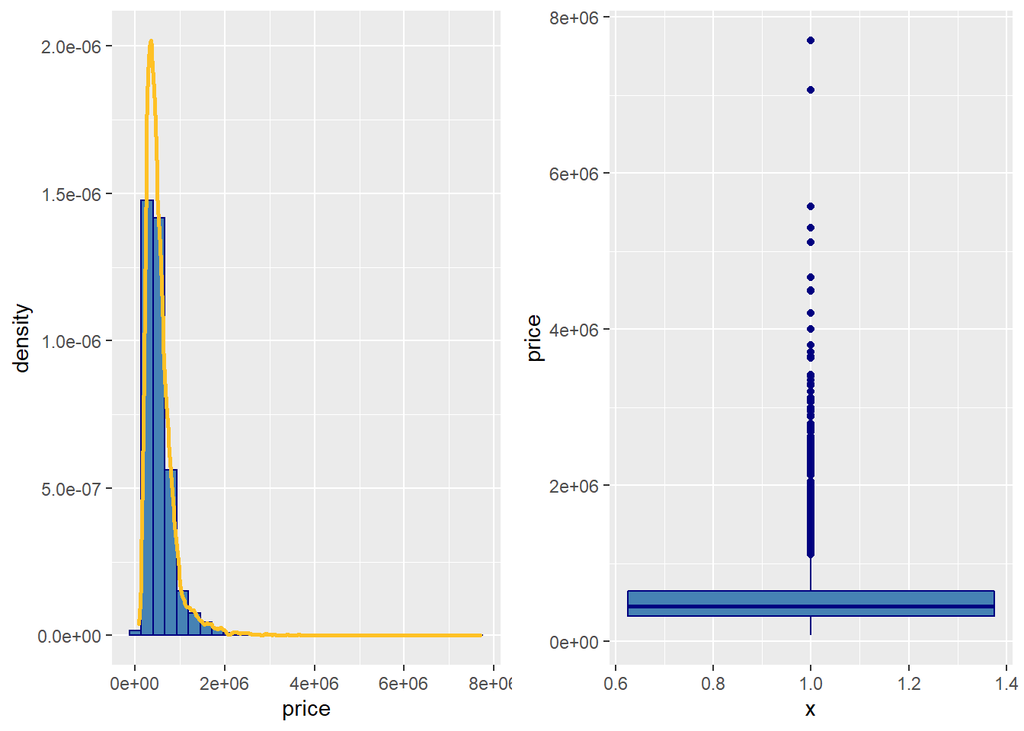

```r
p1 <- ggplot(train, aes(x=price)) + geom_histogram(aes(y=..density..), colour = "navy", fill = "steelblue", bins=30) + geom_density(colour = "goldenrod1", size = 1)
p2 <- ggplot(train, aes(x=1)) + geom_boxplot(aes(y=price), colour = "navy", fill = "steelblue")
grid.arrange(p1, p2, nrow=1)
```

```r
summary(train$price)
```

```
##    Min. 1st Qu.  Median    Mean 3rd Qu.    Max.
##   75000  324774  450000  537578  640000 7700000
```

Se estudia la variable **sqft_living**

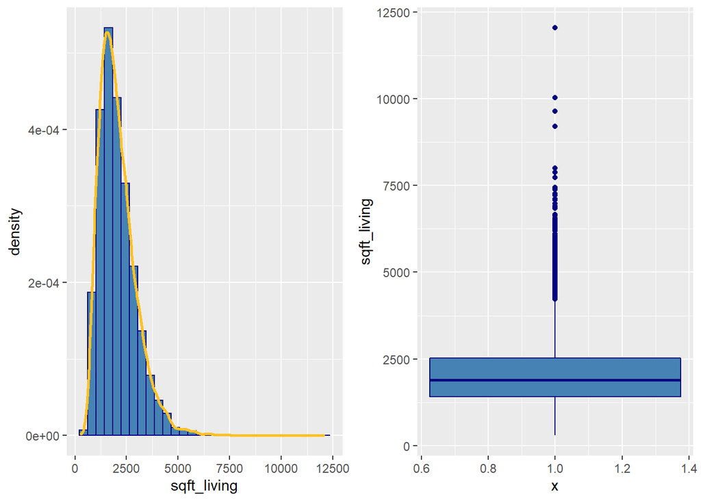

```r
p3 <- ggplot(train, aes(x=sqft_living)) + geom_histogram(aes(y=..density..), colour = "navy", fill = "steelblue", bins=30) + geom_density(colour = "goldenrod1", size = 1)
p4 <- ggplot(train, aes(x=1)) + geom_boxplot(aes(y=sqft_living), colour = "navy", fill = "steelblue")
grid.arrange(p3, p4, nrow=1)
```

```r
summary(train$sqft_living)
```

```
##    Min. 1st Qu.  Median    Mean 3rd Qu.    Max.
##     290    1410    1890    2064    2530   12050
```

Se estudia la variable **sqft_living15**

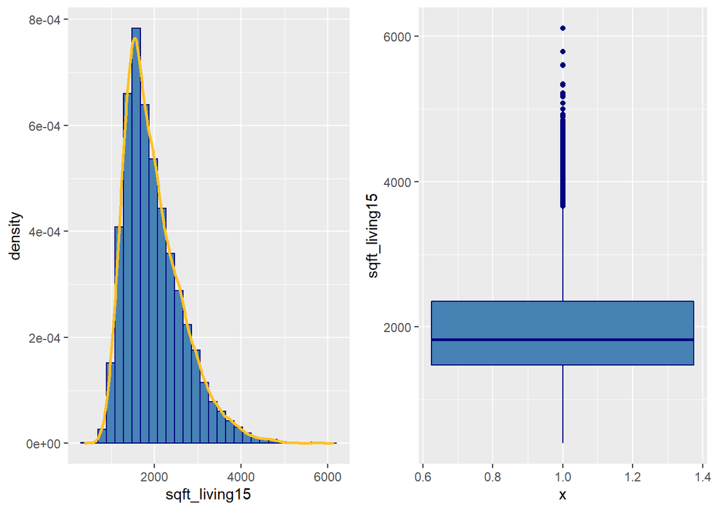

```r
p5 <- ggplot(train, aes(x=sqft_living15)) + geom_histogram(aes(y=..density..), colour = "navy", fill = "steelblue", bins=30) + geom_density(colour = "goldenrod1", size = 1)
p6 <- ggplot(train, aes(x=1)) + geom_boxplot(aes(y=sqft_living15), colour = "navy", fill = "steelblue")
grid.arrange(p5, p6, nrow=1)
```

```r
summary(train$sqft_living15)
```

```
##    Min. 1st Qu.  Median    Mean 3rd Qu.    Max.
##     399    1480    1830    1977    2350    6110
```

Se estudia la variable **sqft_lot**

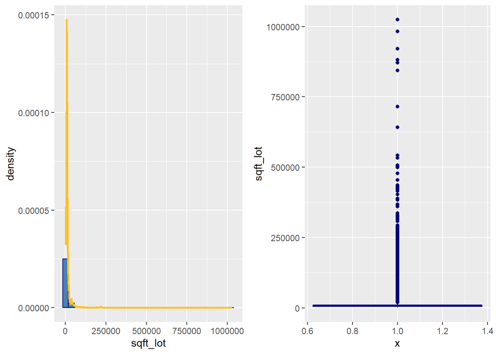

```r
p7 <- ggplot(train, aes(x=sqft_lot)) + geom_histogram(aes(y=..density..), colour = "navy", fill = "steelblue", bins=30) + geom_density(colour = "goldenrod1", size = 1)
p8 <- ggplot(train, aes(x=1)) + geom_boxplot(aes(y=sqft_lot), colour = "navy", fill = "steelblue")
grid.arrange(p7, p8, nrow=1)
```

```r
summary(train$sqft_lot)
```

```
##    Min. 1st Qu.  Median    Mean 3rd Qu.    Max.
##     572    5000    7492   14621   10498 1024068
```

Se estudia la variable **sqft_lot15**

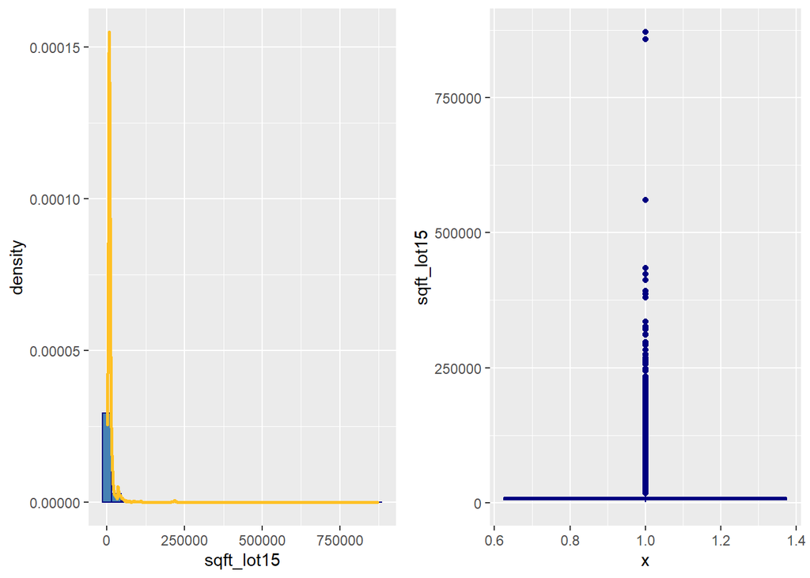

```r
p9 <- ggplot(train, aes(x=sqft_lot15)) + geom_histogram(aes(y=..density..), colour = "navy", fill = "steelblue", bins=30) + geom_density(colour = "goldenrod1", size = 1)
p10 <- ggplot(train, aes(x=1)) + geom_boxplot(aes(y=sqft_lot15), colour = "navy", fill = "steelblue")
grid.arrange(p9, p10, nrow=1)
```

```r
summary(train$sqft_lot15)
```

```
##    Min. 1st Qu.  Median    Mean 3rd Qu.    Max.
##     659    5000    7507   12520   10000  871200
```

Se estudia la variable **sqft_above**

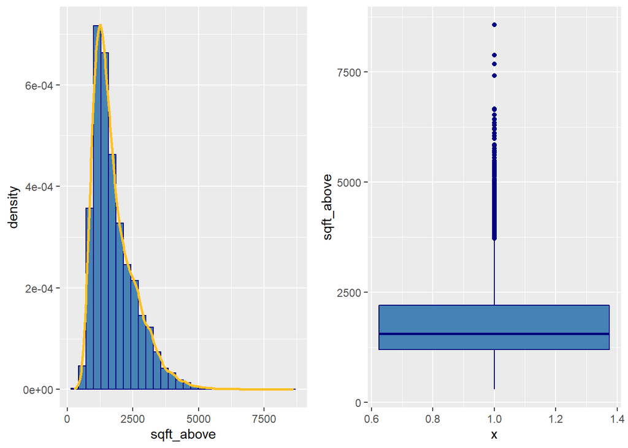

```r
p11 <- ggplot(train, aes(x=sqft_above)) + geom_histogram(aes(y=..density..), colour = "navy", fill = "steelblue", bins=30) + geom_density(colour = "goldenrod1", size = 1)
p12 <- ggplot(train, aes(x=1)) + geom_boxplot(aes(y=sqft_above), colour = "navy", fill = "steelblue")
grid.arrange(p11, p12, nrow=1)
```

```r
summary(train$sqft_above)
```

```
##    Min. 1st Qu.  Median    Mean 3rd Qu.    Max.    NA's
##     290    1190    1560    1781    2200    8570       1
```

Se estudia la variable **sqft_basement**

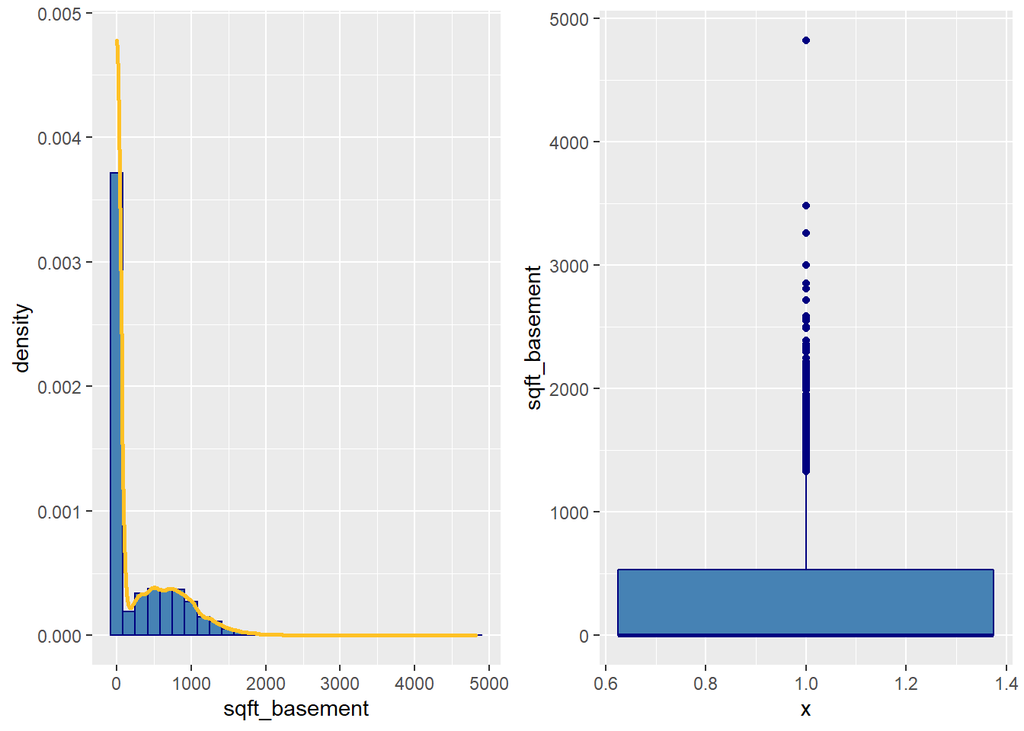

```r
p13 <- ggplot(train, aes(x=sqft_basement)) + geom_histogram(aes(y=..density..), colour = "navy", fill = "steelblue", bins=30) + geom_density(colour = "goldenrod1", size = 1)
p14 <- ggplot(train, aes(x=1)) + geom_boxplot(aes(y=sqft_basement), colour = "navy", fill = "steelblue")
grid.arrange(p13, p14, nrow=1)
```

```r
summary(train$sqft_basement)
```

```
##    Min. 1st Qu.  Median    Mean 3rd Qu.    Max.
##     0.0     0.0     0.0   282.4   530.0  4820.0
```

Se estudia la variable **yr_built**

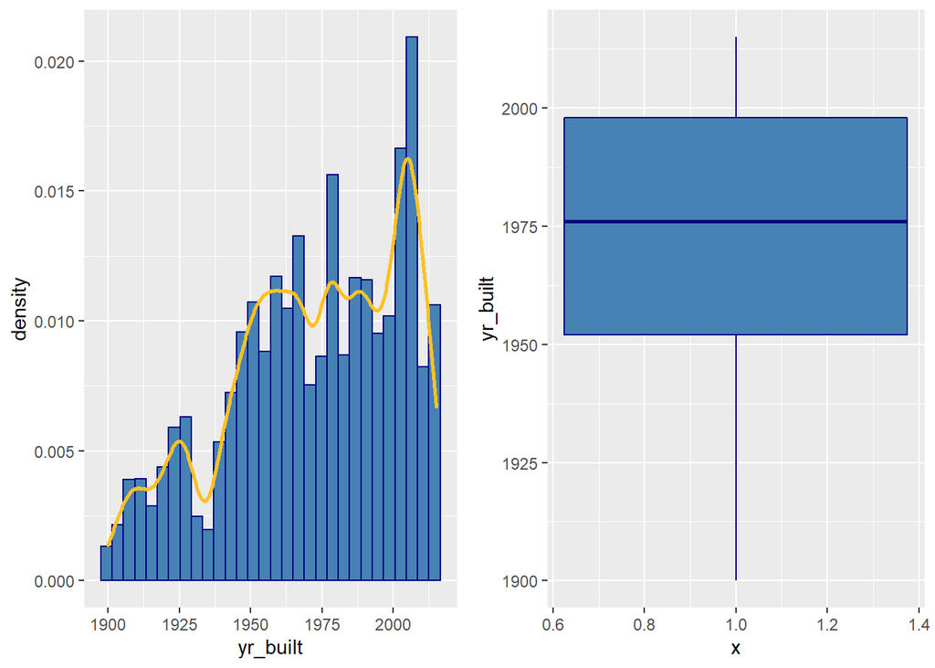

```r
p15 <- ggplot(train, aes(x=yr_built)) + geom_histogram(aes(y=..density..), colour = "navy", fill = "steelblue", bins=30) + geom_density(colour = "goldenrod1", size = 1)
p16 <- ggplot(train, aes(x=1)) + geom_boxplot(aes(y=yr_built), colour = "navy", fill = "steelblue")
grid.arrange(p15, p16, nrow=1)
```

```r
summary(train$yr_built)
```

```
##    Min. 1st Qu.  Median    Mean 3rd Qu.    Max.
##    1900    1952    1976    1972    1998    2015
```

Se estudia la variable **yr_renovated**

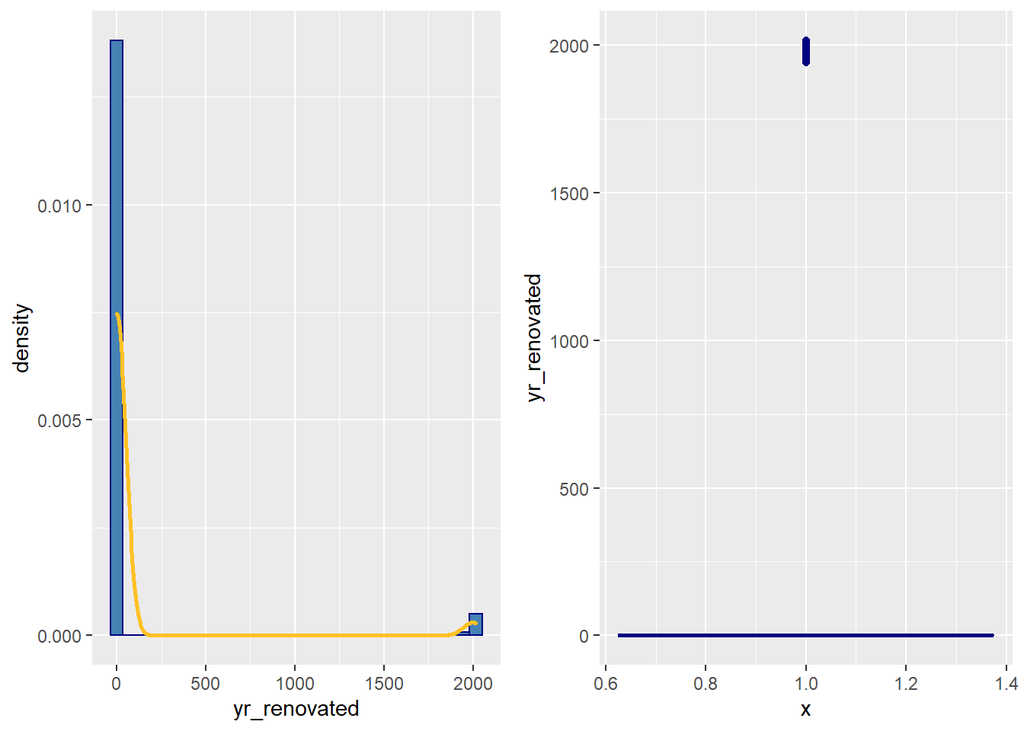

```r
p17 <- ggplot(train, aes(x=yr_renovated)) + geom_histogram(aes(y=..density..), colour = "navy", fill = "steelblue", bins=30) + geom_density(colour = "goldenrod1", size = 1)
p18 <- ggplot(train, aes(x=1)) + geom_boxplot(aes(y=yr_renovated), colour = "navy", fill = "steelblue")
grid.arrange(p17, p18, nrow=1)
```

```r
summary(train$yr_renovated)
```

```
##    Min. 1st Qu.  Median    Mean 3rd Qu.    Max.
##    0.00    0.00    0.00   81.08    0.00 2015.00
```

### Variables cualitativas

```r
var_cual <- train[, c("date", "bedrooms", "bathrooms", "floors", "waterfront" , "view" , "condition", "grade", "zipcode")]
str(var_cual)
```

```
## 'data.frame':    15979 obs. of  9 variables:
##  $ date      : chr  "20140602T000000" "20150406T000000" "20140619T000000" "20140825T000000" ...
##  $ bedrooms  : int  4 3 4 4 5 3 3 3 4 3 ...
##  $ bathrooms : num  3.25 2.5 2 1.75 2.75 1 2.5 1.75 2.25 2.5 ...
##  $ floors    : num  2 1.5 1 1 1.5 1.5 1.5 1 1 1 ...
##  $ waterfront: int  0 0 0 0 0 0 0 0 0 0 ...
##  $ view      : int  0 0 0 0 3 0 3 0 3 0 ...
##  $ condition : int  4 4 4 4 5 4 3 4 4 4 ...
##  $ grade     : int  9 9 7 7 7 7 10 7 7 8 ...
##  $ zipcode   : int  98022 98022 98022 98022 98022 98022 98022 98022 98022 98022 ...
```

Se estudia la variable **date**

```r
dtdate <- gsub("T000000","",as.character(train$date))
dtdate <- as.data.frame(dtdate)
dtdate <- as.Date(dtdate[, 'dtdate'],'%Y%m%d')
str(dtdate)
```

```
##  Date[1:15979], format: "2014-06-02" "2015-04-06" "2014-06-19" "2014-08-25" "2015-02-13" ...
```

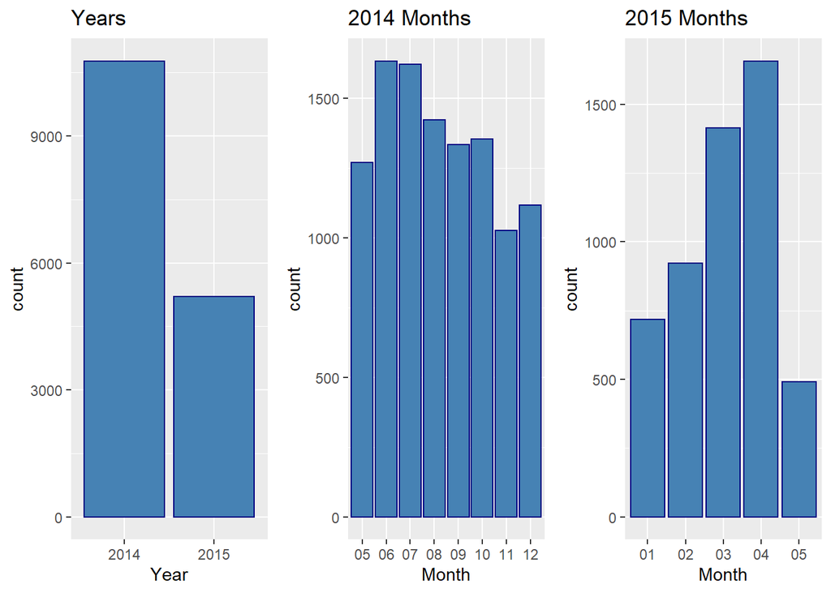

```r
Month <- format(dtdate,"%m")
Year <- format(dtdate,"%Y")
df_dateMix <- data.frame(Month, Year)
df_date2014 <- subset(df_dateMix, Year == 2014)
df_date2015 <- subset(df_dateMix, Year == 2015)
p1 <- ggplot(df_dateMix, aes(x=Year)) + geom_bar(colour = "navy", fill = "steelblue") + ggtitle("Years")
p2 <- ggplot(df_date2014, aes(x=Month)) + geom_bar(colour = "navy", fill = "steelblue") + ggtitle("2014 Months")
p3 <- ggplot(df_date2015, aes(x=Month)) + geom_bar(colour = "navy", fill = "steelblue") + ggtitle("2015 Months")

grid.arrange(p1, p2, p3, nrow=1)
```

```r
summary(dtdate)
```

```
##         Min.      1st Qu.       Median         Mean      3rd Qu.         Max.
## "2014-05-02" "2014-07-22" "2014-10-16" "2014-10-30" "2015-02-18" "2015-05-14"
```

Se estudian las variable **bedrooms, bathrooms, floors**

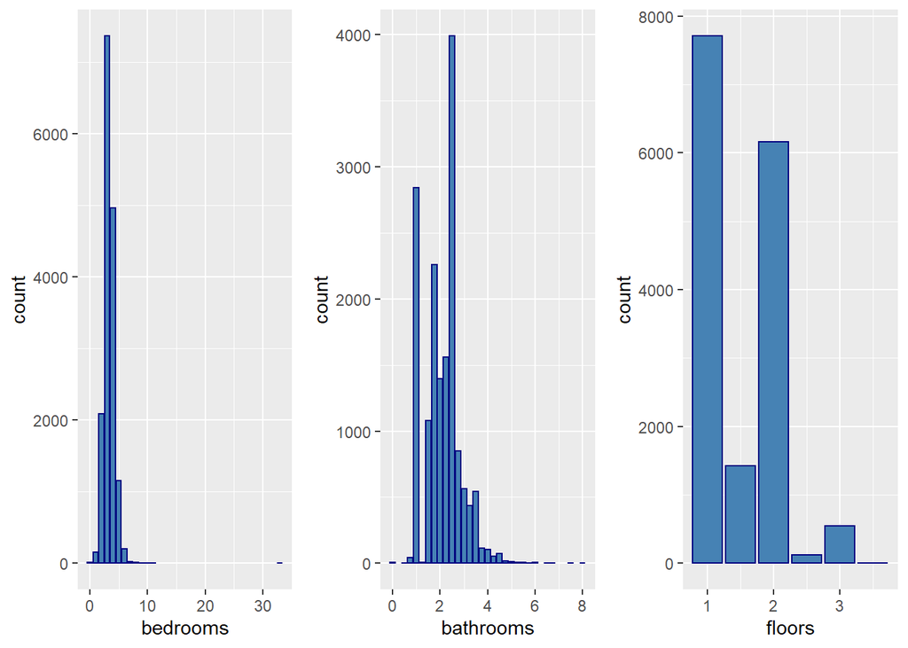

```r
p1 <- ggplot(train, aes(x=bedrooms)) + geom_bar(colour = "navy", fill = "steelblue")
p2 <- ggplot(train, aes(x=bathrooms)) + geom_bar(colour = "navy", fill = "steelblue")
p3 <- ggplot(train, aes(x=floors)) + geom_bar(colour = "navy", fill = "steelblue")

grid.arrange(p1, p2, p3, nrow=1)
```

Se estudian las variable **waterfront, view**

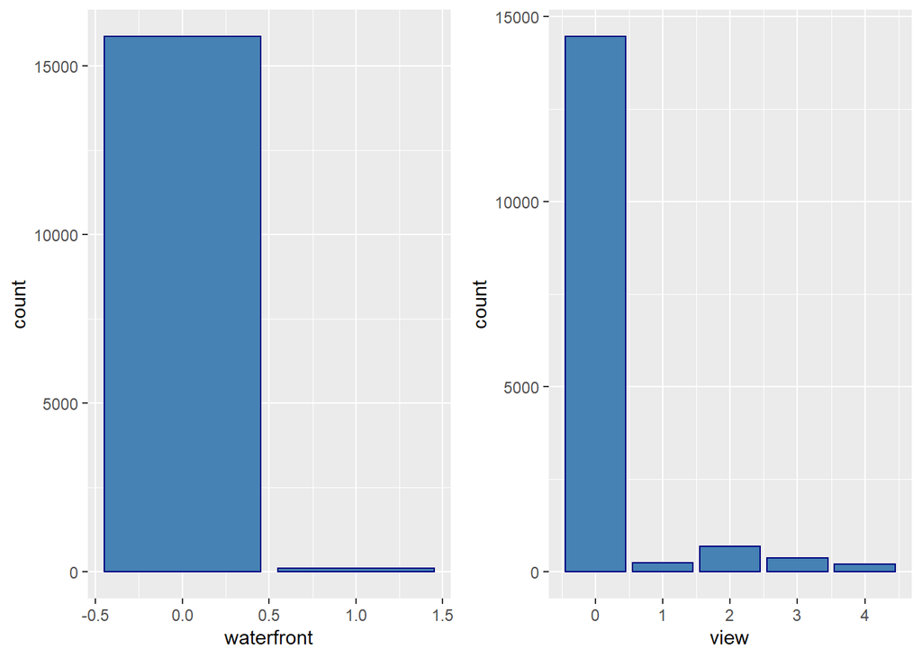

```r
p1 <- ggplot(train, aes(x=waterfront)) + geom_bar(colour = "navy", fill = "steelblue")
p2 <- ggplot(train, aes(x=view)) + geom_bar(colour = "navy", fill = "steelblue")

grid.arrange(p1, p2, nrow=1)
```

Se estudian las variable **condition, grade**

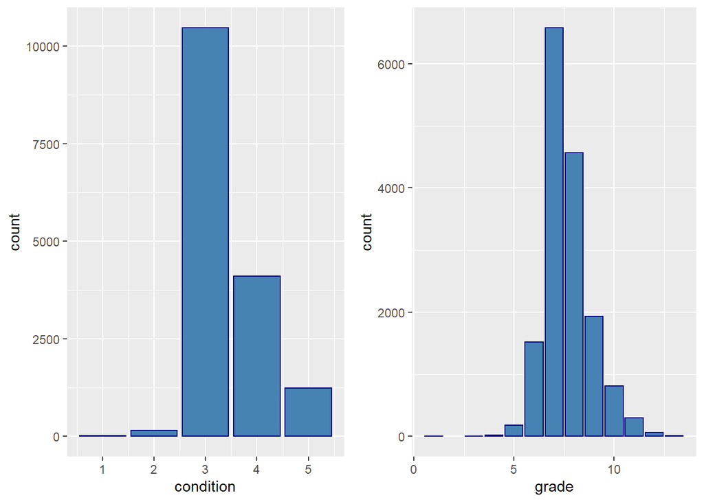

```r
p1 <- ggplot(train, aes(x=condition)) + geom_bar(colour = "navy", fill = "steelblue")
p2 <- ggplot(train, aes(x=grade)) + geom_bar(colour = "navy", fill = "steelblue")

grid.arrange(p1, p2, nrow=1)
```

Se estudia la variable **zipcode**

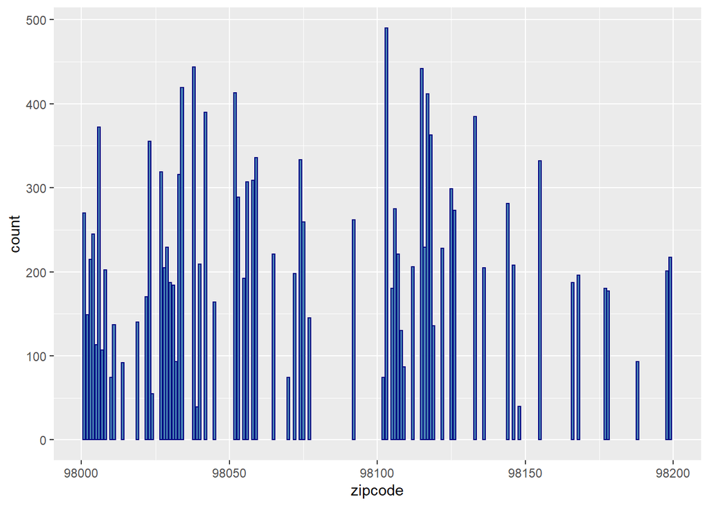

```r
ggplot(train, aes(x=zipcode)) + geom_bar(colour = "navy", fill = "steelblue")
```

### Creación de nuevas variables

**Variables**

Una vez estudiadas las variables, se crean variables en base a **price y date** extrayendo el **año, mes, trimestre, antigüedad, años desde la renovación, y el precio por metro cuadrado.**

```r
train$sale_date = substr(train$date, 1, 8)
train = transform(train, sale_date = as.Date(as.character(sale_date), "%Y%m%d"))
train$sale_year = as.numeric(format(train$sale_date, format="%Y"))
train$sale_month = format(train$sale_date, format="%m")
train$sale_quarter = as.yearqtr(train$sale_date)
train$sale_quarter = str_sub(train$sale_quarter,-2,-1)
train$sale_tenure =  as.numeric(train$sale_year) - train$yr_built
train$yr_since_last_renovated = ifelse(train$sale_year - train$yr_renovated > 2013, 0, train$sale_year - train$yr_renovated)
train$price_m2 = train$price/train$sqft_living
str(train)
```

```
## 'data.frame':    15979 obs. of  30 variables:
##  $ lat                    : num  47.2 47.2 47.2 47.2 47.2 ...
##  $ long                   : num  -122 -122 -122 -122 -122 ...
##  $ id                     : num  6.19e+08 6.19e+08 6.19e+08 3.42e+09 3.22e+09 ...
##  $ date                   : chr  "20140602T000000" "20150406T000000" "20140619T000000" "20140825T000000" ...
##  $ price                  : int  687000 750000 335000 360000 432000 230000 790000 265000 350000 330000 ...
##  $ bedrooms               : int  4 3 4 4 5 3 3 3 4 3 ...
##  $ bathrooms              : num  3.25 2.5 2 1.75 2.75 1 2.5 1.75 2.25 2.5 ...
##  $ sqft_living            : int  4400 2350 2030 3730 2060 1530 2640 1820 1570 2060 ...
##  $ sqft_lot               : int  186846 715690 103672 16980 329903 389126 432036 32666 499571 25046 ...
##  $ floors                 : num  2 1.5 1 1 1.5 1.5 1.5 1 1 1 ...
##  $ waterfront             : int  0 0 0 0 0 0 0 0 0 0 ...
##  $ view                   : int  0 0 0 0 3 0 3 0 3 0 ...
##  $ condition              : int  4 4 4 4 5 4 3 4 4 4 ...
##  $ grade                  : int  9 9 7 7 7 7 10 7 7 8 ...
```

[output cut: 16 more lines]

Se estudian las variable **sale_year, sale_month, sale_quarter**

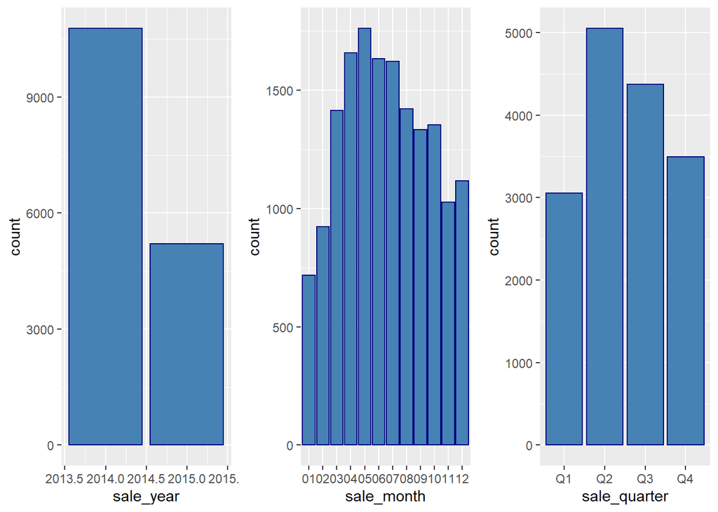

```r
p1 <- ggplot(train, aes(x=sale_year)) + geom_bar(colour = "navy", fill = "steelblue")
p2 <- ggplot(train, aes(x=sale_month)) + geom_bar(colour = "navy", fill = "steelblue")
p3 <- ggplot(train, aes(x=sale_quarter)) + geom_bar(colour = "navy", fill = "steelblue")

grid.arrange(p1, p2, p3, nrow=1)
```

Se estudian las variable **sale_tenure, yr_since_last_renovated2**

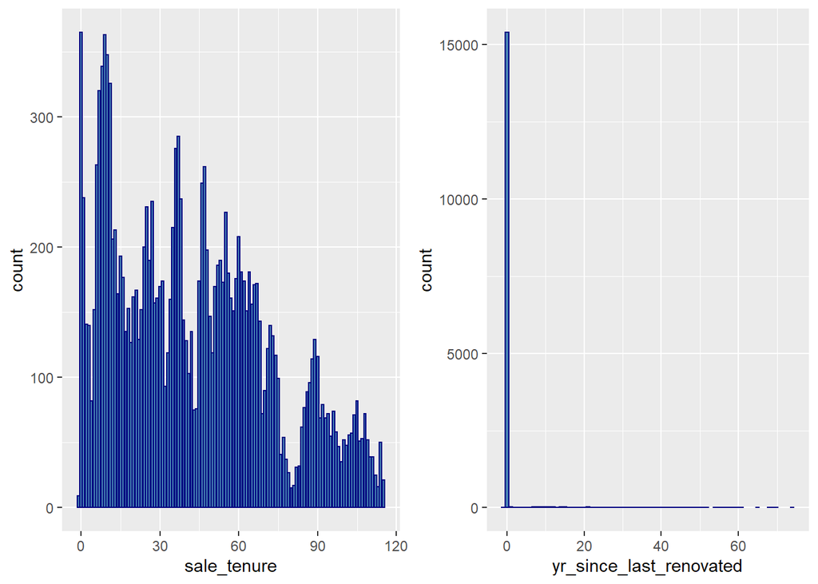

```r
p1 <- ggplot(train, aes(x=sale_tenure)) + geom_bar(colour = "navy", fill = "steelblue")
p2 <- ggplot(train, aes(x=yr_since_last_renovated)) + geom_bar(colour = "navy", fill = "steelblue")
grid.arrange(p1, p2, nrow=1)
```

Se estudian las variable **price_m2**

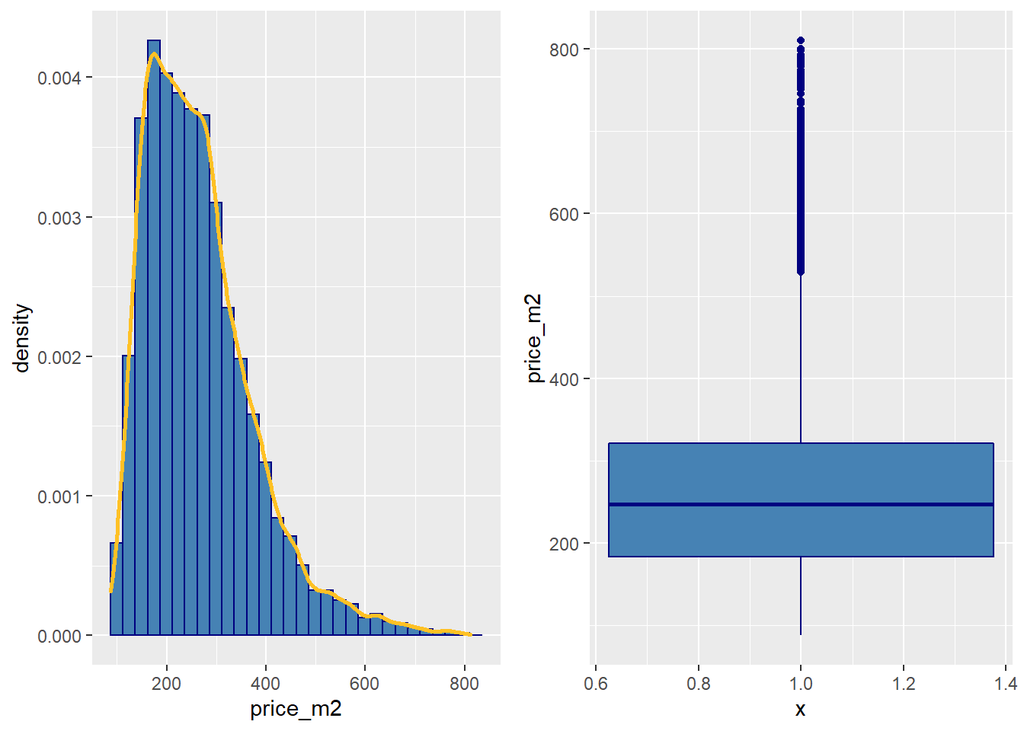

```r
p3 <- ggplot(train, aes(x=price_m2)) + geom_histogram(aes(y=..density..), colour = "navy", fill = "steelblue", bins=30) + geom_density(colour = "goldenrod1", size = 1)
p4 <- ggplot(train, aes(x=1)) + geom_boxplot(aes(y=price_m2), colour = "navy", fill = "steelblue")

grid.arrange(p3, p4, nrow=1)
```

### Analisis multivariante cuantitativo

Se estudia la correlación entre las variables **sqft_living“**,** ”sqft_lot“**,** ”sqft_living15“**,** ”sqft_basement“**,** ”sqft_above“**,** ”price“**,** ”price_m2“**,** ”Dist_from_seattle"** y **“Sale_tenure”**.

```r
am_cuant <- train %>% select("price","Dist_from_seattle","price_m2", "sqft_living","sqft_lot", "sqft_above", "sqft_basement", "yr_built", "yr_renovated", "sqft_living15", "sqft_lot15","sale_tenure")

amc1 <- c("sqft_living", "sqft_lot", "sqft_living15", "sqft_basement", "sqft_above","price","price_m2","Dist_from_seattle","sale_tenure")
amc2 <- c("yr_built", "yr_renovated", "price")



#Correlación numérica entre variables
corr <- am_cuant %>% na.omit() %>% cor()

#Correlaciones importantes
as.data.frame(as.table(corr)) %>% subset(., abs(Freq) > 0.4) %>% subset(., abs(Freq) != 1) %>% .[order(.$Freq, decreasing = TRUE),] %>%
  .[c(seq(1, nrow(.), by=2)),]
```

```
##             Var1              Var2       Freq
## 42    sqft_above       sqft_living  0.8771298
## 46 sqft_living15       sqft_living  0.7594122
## 59    sqft_lot15          sqft_lot  0.7463109
## 70 sqft_living15        sqft_above  0.7343764
## 4    sqft_living             price  0.7027395
## 6     sqft_above             price  0.6052003
## 10 sqft_living15             price  0.5840427
## 3       price_m2             price  0.5467182
## 43 sqft_basement       sqft_living  0.4351781
## 68      yr_built        sqft_above  0.4124471
## 72   sale_tenure        sqft_above -0.4128012
## 15      price_m2 Dist_from_seattle -0.5547658
## 96   sale_tenure          yr_built -0.9998746
```

Se puede observar que las variables con mayor correlación son: **“sqft_above”** y **“sqft_living”** **“sqft_living15”** y **“sqft_linving”**. Se debe a que es la misma variable actualizada. **“price_m2”** y **“price”**. **“yr_built”** y **“sqft_above”**. Sorprendente. Puede deberse a normativa.

```r
am_cuant1 <- am_cuant %>% select(amc1) %>% na.omit() %>% ggcorr()
```

```
## Note: Using an external vector in selections is ambiguous.
## i Use `all_of(amc1)` instead of `amc1` to silence this message.
## i See <https://tidyselect.r-lib.org/reference/faq-external-vector.html>.
```

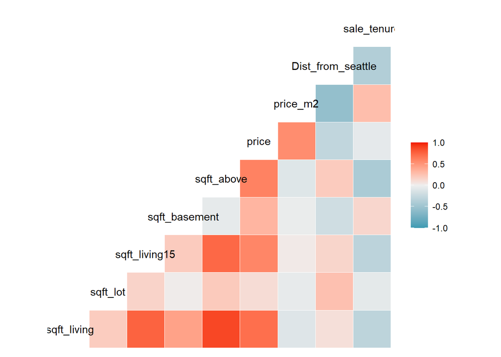

```r
grid.arrange(am_cuant1, nrow=1)
```

De igual forma en el anterior grafico encontramos las mismas correlaciones entre variables.

Relación entre la variable **“sqft_above” y “sqft_living”**.

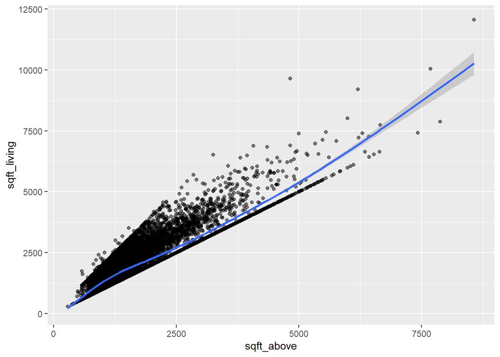

```r
ggplot(train,aes(x=sqft_above,y=sqft_living))+geom_point(alpha=0.5)+geom_smooth()
```

Relación entre **“sqft_living”** y **“sqft_living15”**.

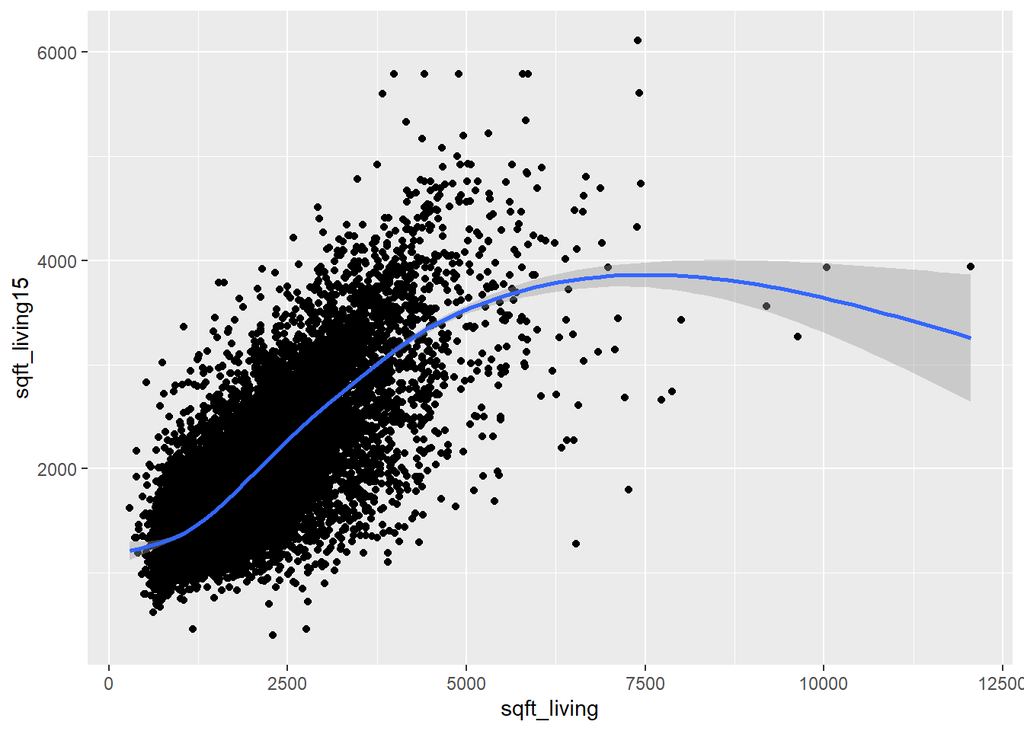

```r
ggplot(train,aes(x=sqft_living,y=sqft_living15))+geom_point()+geom_smooth()
```

Relación entre **“Dist_from_seattle”** y **“price_m2”**.

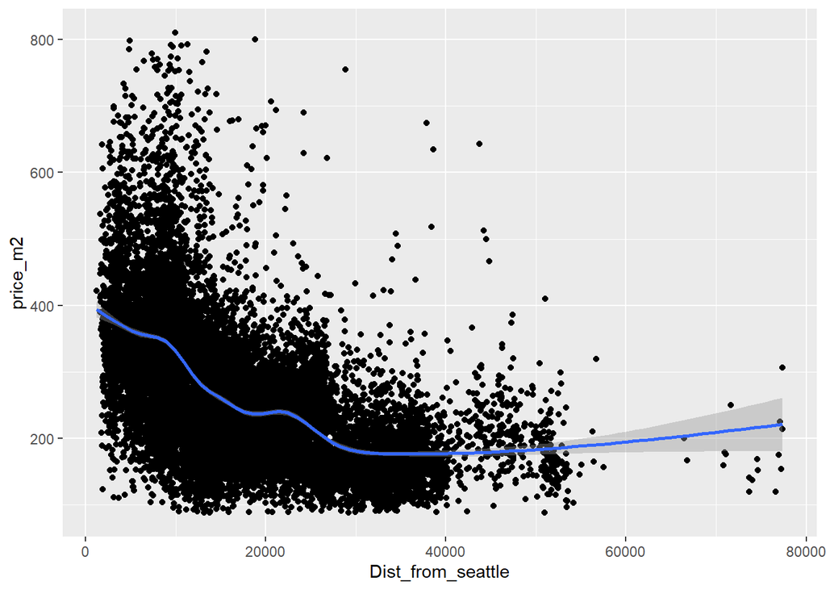

```r
ggplot(train,aes(x=Dist_from_seattle,y=price_m2))+geom_point()+geom_smooth()
```

Podemos observar que existe una relación entre el precio por metro cuadrado de la vivienda con su cercanía al centro de Seattle.

Relación entre **“Dist_from_seattle” y “price”**.

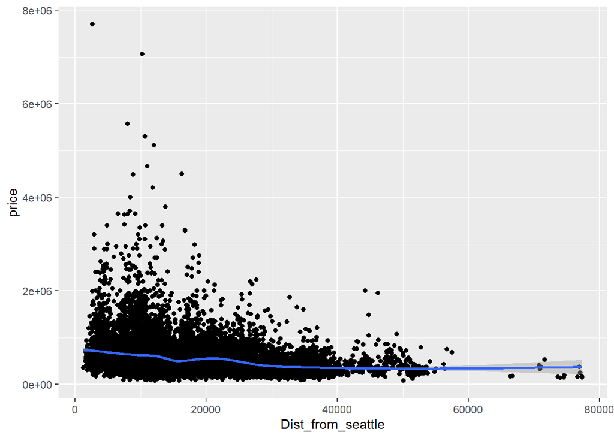

```r
ggplot(train,aes(x=Dist_from_seattle,y=price))+geom_point()+geom_smooth()
```

Relación entre **“sqft_above” y “price”**

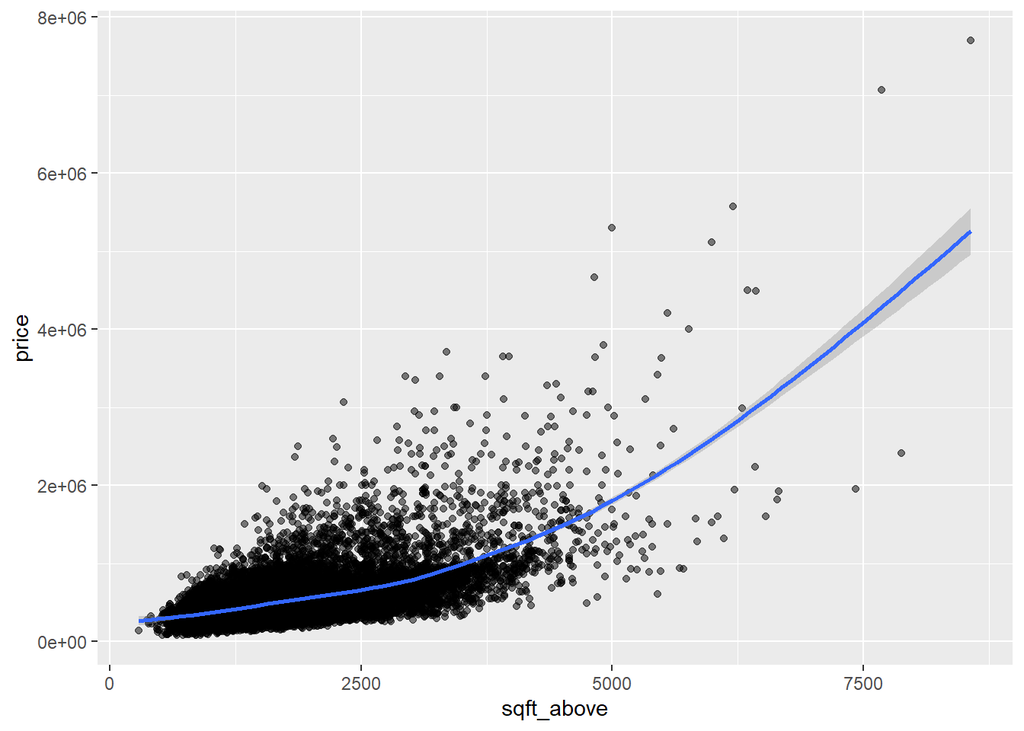

```r
ggplot(train,aes(x=sqft_above,y=price))+geom_point(alpha=0.5)+geom_smooth()
```

Relación entre **“sqft_living” y “price”**

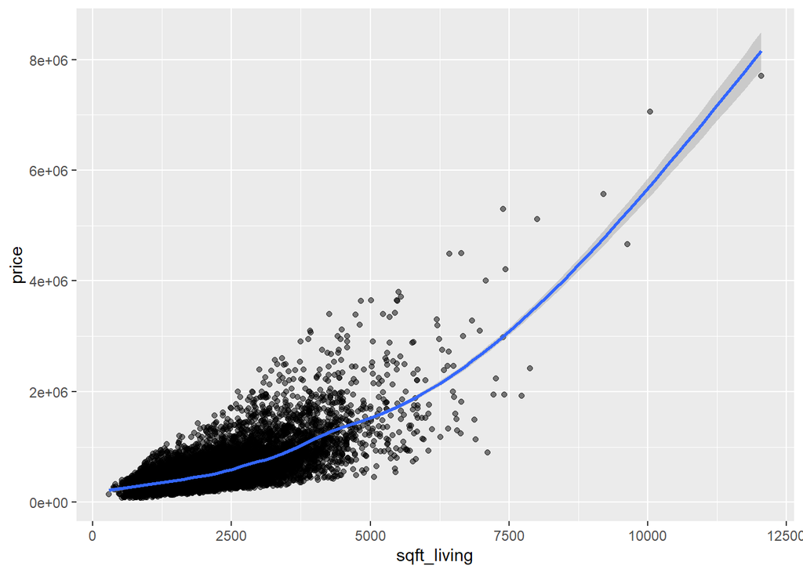

```r
ggplot(train,aes(x=sqft_living,y=price))+geom_point(alpha=0.5)+geom_smooth()
```

Relación entre la variable **“sqft_above” y “price_m2”**.

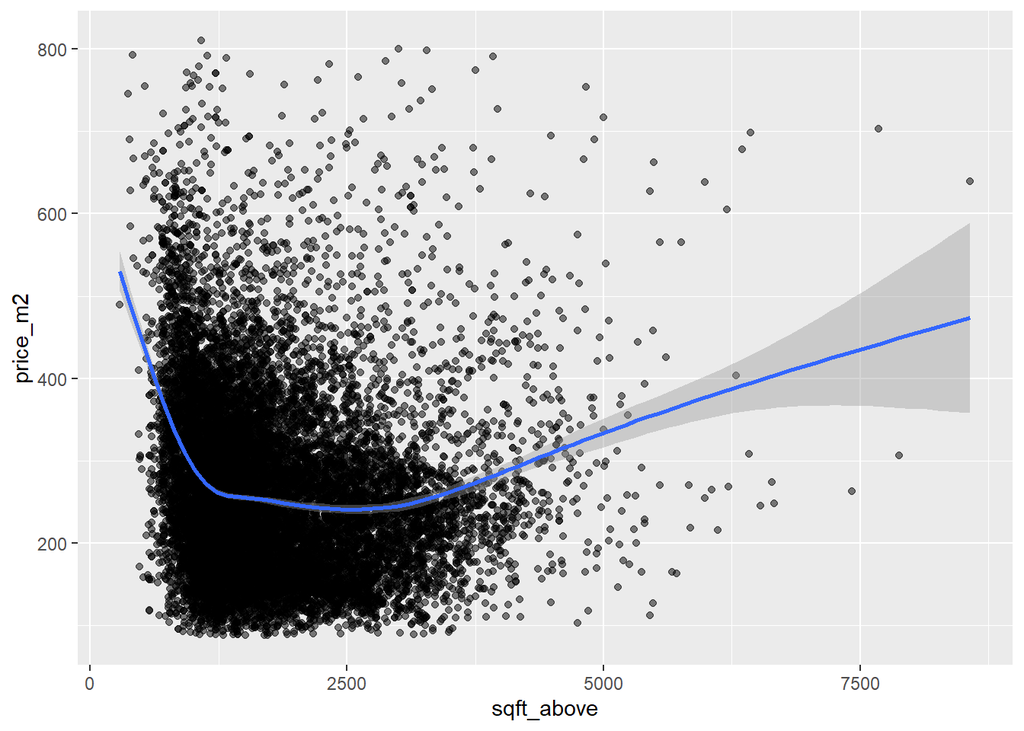

```r
ggplot(train,aes(x=sqft_above,y=price_m2))+geom_point(alpha=0.5)+geom_smooth()
```

Relación entre la variable **“sqft_living” y “price_m2”**.

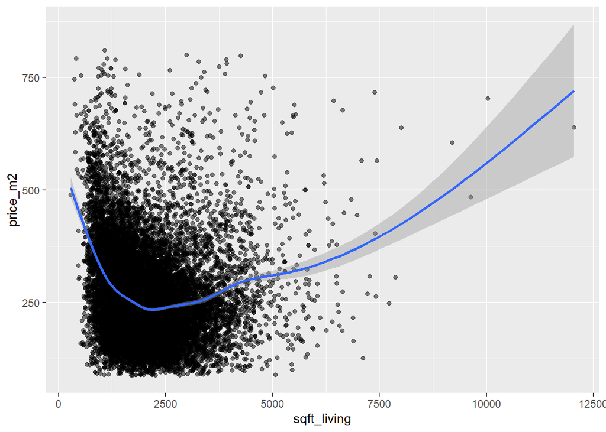

```r
ggplot(train,aes(x=sqft_living,y=price_m2))+geom_point(alpha=0.5)+geom_smooth()
```

### Analisis multivariante cualitativo

```r
am_cual <- train %>% select("date","sale_date", "sale_year", "sale_month", "bedrooms", "bathrooms", "waterfront", "view", "condition", "grade", "zipcode","lat", "long","price","price_m2","sale_tenure")
am1 <- c("bedrooms", "bathrooms","condition","grade","price","price_m2","sale_tenure")

#Correlación numérica entre variables
corr <- am_cual %>% select(am1) %>% na.omit() %>% cor()
```

```
## Note: Using an external vector in selections is ambiguous.
## i Use `all_of(am1)` instead of `am1` to silence this message.
## i See <https://tidyselect.r-lib.org/reference/faq-external-vector.html>.
```

```r
#Correlaciones importantes
as.data.frame(as.table(corr)) %>% subset(., abs(Freq) > 0.4) %>% subset(., abs(Freq) != 1) %>% .[order(.$Freq, decreasing = TRUE),] %>%
  .[c(seq(1, nrow(.), by=2)),]
```

```
##           Var1      Var2       Freq
## 26       price     grade  0.6666301
## 11       grade bathrooms  0.6621299
## 34    price_m2     price  0.5467127
## 12       price bathrooms  0.5224438
## 2    bathrooms  bedrooms  0.4969860
## 28 sale_tenure     grade -0.4449885
## 14 sale_tenure bathrooms -0.5078983
```

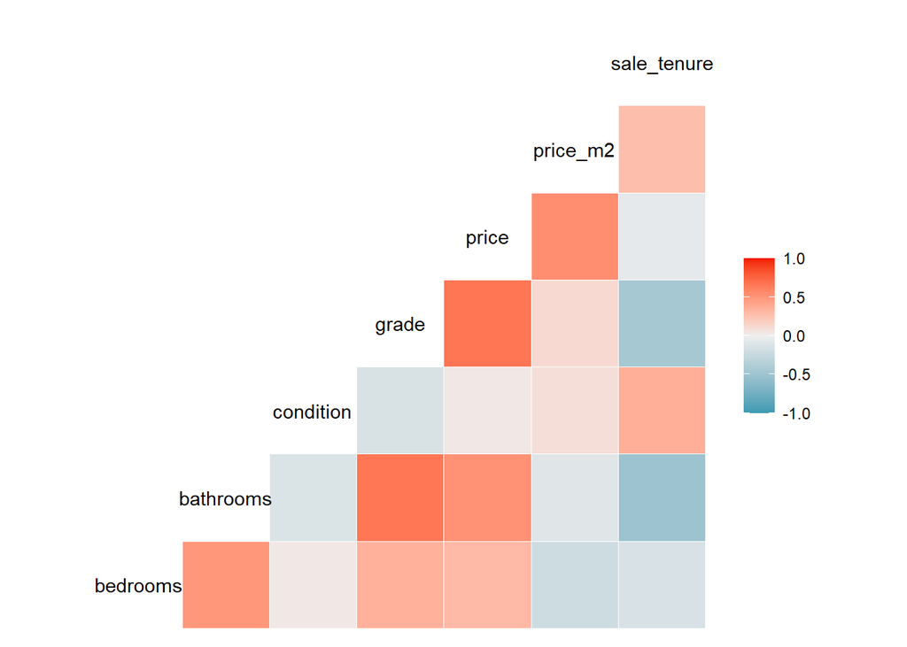

```r
am_cual1 <- am_cual %>% select(am1) %>% na.omit() %>% ggcorr()
grid.arrange(am_cual1, nrow=1)
```

Se encuentra una correlación alta entre **“bathrooms”** y **“grade”**

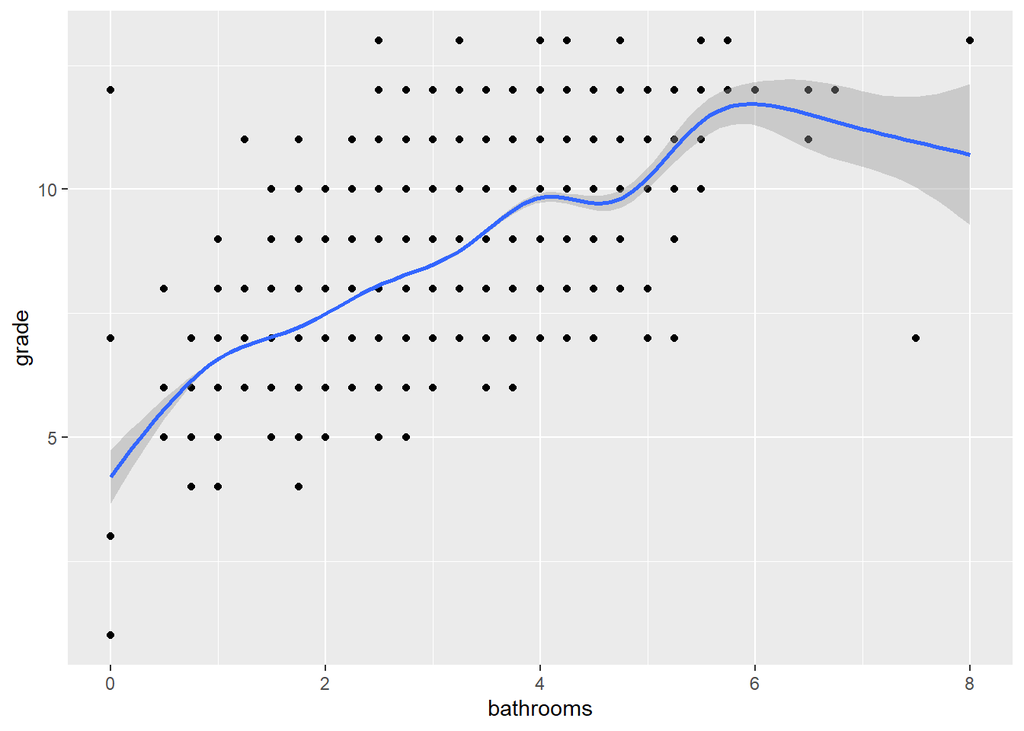

```r
ggplot(train,aes(x=bathrooms,y=grade))+geom_point()+geom_smooth()
```

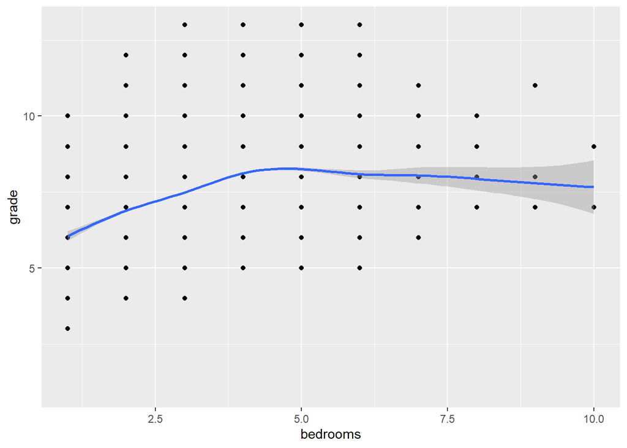

```r
ggplot(train,aes(x=bedrooms,y=grade,))+geom_point()+geom_smooth()+scale_x_continuous(limits=c(1,10))
```

Relación entre **“grade” y “price”**.

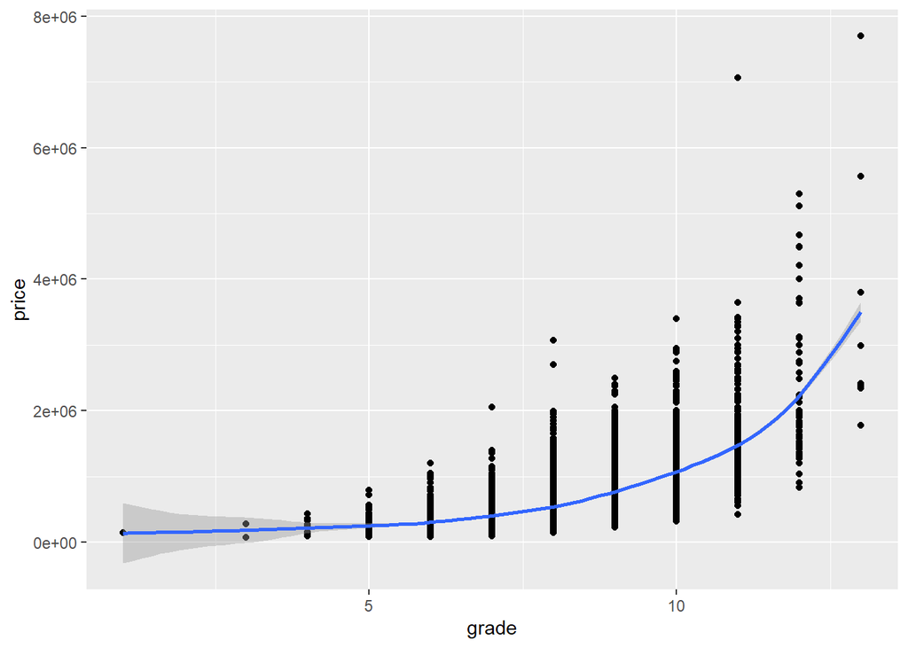

```r
ggplot(train,aes(x=grade,y=price))+geom_point()+geom_smooth()
```

Relación entre **“grade” y “price_m2”**.

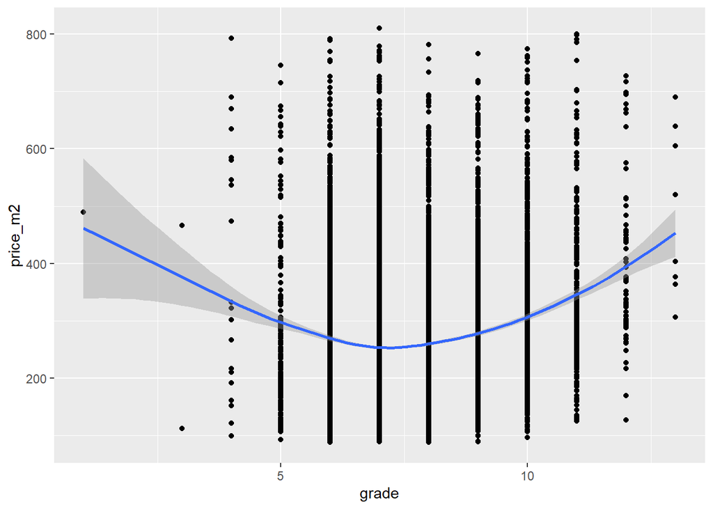

```r
ggplot(train,aes(x=grade,y=price_m2))+geom_point()+geom_smooth()
```

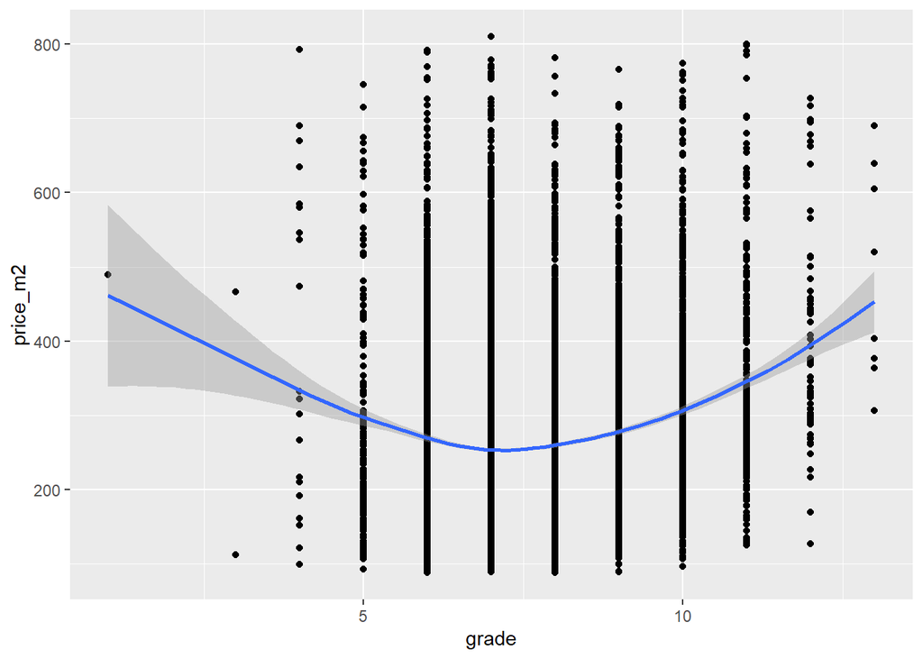

```r
ggplot(train,aes(x=grade,y=price_m2))+geom_point()+geom_smooth()
```